# Relação entre a variação da taxa SELIC e o ROE dos maiores bancos brasileiros no século XXI

Juan Doudement

2025-11-06

## 1 - Introdução

#### Como parte da minha monografia em Ciências Econômicas, estou investigando a relação entre a variação da taxa SELIC e o desempenho dos principais bancos brasileiros, com foco especial no ROE (Return on Equity). A motivação é simples: há um discurso recorrente de que “os banqueiros influenciam a SELIC para melhorar seus resultados”. Antes de aceitar ou rejeitar essa ideia, é fundamental analisar os dados com rigor.

## 2 - Metodolgia

#### O ROE é importante porque mostra, de forma direta, quanto a instituição consegue gerar de retorno para cada 1 real de patrimônio líquido. Em outras palavras, um ROE de 15% indica que a cada R$ 1 de patrimônio, o banco gera R$ 0,15 de lucro líquido por ano. O cálculo é feito de forma simples com (Lucro Líquido/Patrimônio Líquido).

$$\text{ROE} = \frac{\text{Lucro Líquido}}{\text{Patrimônio Líquido}}$$

#### Os dados foram coletados no IF Data (BACEN) e tratados no R. Embora no PDF não apareçam todas as etapas de manipulação, os cálculos e transformações necessários já foram previamente realizados.

#### O modelo VAR é apropriado para séries temporais porque captura como cada variável é influenciada tanto pelos seus próprios valores passados quanto pelos valores passados das demais variáveis do sistema.

$$\begin{aligned}
ROE \quad (y_{1,t}) &= c_1 + \sum_{i=1}^{p} \alpha_{1,i} y_{1,t-i} +
\sum_{i=1}^{p} \beta_{1,i} y_{2,t-i} + \epsilon_{1,t} \\
SELIC \quad (y_{2,t}) &= c_2 + \sum_{i=1}^{p} \alpha_{2,i} y_{1,t-i}
+ \sum_{i=1}^{p} \beta_{2,i} y_{2,t-i} + \epsilon_{2,t}
\end{aligned}$$

#### Quanto à taxa SELIC, foi necessário convertê-la para frequência trimestral, já que sua atualização ocorre aproximadamente a cada 44/45 dias. Dessa forma, o valor utilizado para cada trimestre corresponde à taxa registrada no último dia do trimestre. Por exemplo, para o segundo trimestre de 2001, o valor da SELIC associado é o vigente em 30 de junho de 2001.

## 3 - Apresentando o Patrimônio líquido e o Lucro Líquido

#### Carregando os data frames que estão no r.file

```r
load("Juan_Trabalho.RData")
```

#### Para identificar os maiores bancos, filtrei o Ativo Total considerando as seis maiores instituições. Embora o objetivo inicial fosse selecionar apenas cinco, incluí a CAIXA porque ela altera seu código ao longo do tempo, o que poderia distorcer o ranking. A literatura internacional recomenda justamente o uso do Ativo Total como métrica para identificar as maiores instituições financeiras, o que reforça a escolha desse critério.

```r
Ativo_Total <- bind_rows(Ativo) %>%
  filter(TCB == "b1" & (TC == 1 | TC == 2)) %>%
  select(Instituição, Código, Data, `Ativo.Total..k.....i.....j.`, TCB)
Ativo_Total <- Ativo_Total %>%
  rename(
    Ativo_Total = `Ativo.Total..k.....i.....j.`)
```

#### - Demonstração das 5 maiores instituições financeiras

```r
kable(
  head(AT_6, 6),
  col.names = c("TCB", "Código","Data", "media_ativo")) %>%
  kable_styling(full_width = FALSE, bootstrap_options = c("striped"))
```

| TCB | Código | Data | media_ativo |
| --- | --- | --- | --- |
| b1 | 51626 | CAIXA ECONÔMICA FEDERAL | 1699248500 |
| b1 | 30379 | SANTANDER | 1190687098 |
| b1 | 49906 | BB | 1006931415 |
| b1 | 10069 | ITAU | 983022619 |
| b1 | 10045 | BRADESCO | 734809595 |
| b1 | 360305 | CAIXA ECONOMICA FEDERAL | 631808324 |

## 3.1 Filtrando o data frame do Passivo para encontrar o patrimônio líquido

```r
Patrimônio_Líquido <- bind_rows(Passivo)  %>%
  filter(TCB == "b1", Código %in% AT_6$Código) %>%
  dplyr::select(Instituição, Código, Data, `Patrimônio.Líquido..j.`) %>%
  rename(Patrimônio_Líquido = `Patrimônio.Líquido..j.`)
  Patrimônio_Líquido <- na.omit(Patrimônio_Líquido)
```

```r
kable(
  head(Patrimônio_Líquido, 20),
  col.names = c("Instituição", "Código", "Data", "Valor")) %>%
  kable_styling(full_width = FALSE, bootstrap_options = c("striped"))
```

| Instituição | Código | Data | Valor |
| --- | --- | --- | --- |
| BB | 49906 | 03/2000 | 7.316.388 |
| CAIXA ECONOMICA FEDERAL | 360305 | 03/2000 | 3.728.638 |
| BRADESCO | 10045 | 03/2000 | 6.827.064 |
| ITAU | 10069 | 03/2000 | 7.080.473 |
| SANTANDER BRASIL | 30379 | 03/2000 | 1.062.844 |
| BB | 49906 | 03/2001 | 8.101.732 |
| CAIXA ECONOMICA FEDERAL | 360305 | 03/2001 | 2.976.203 |
| BRADESCO | 10045 | 03/2001 | 8.740.552 |
| ITAU | 10069 | 03/2001 | 7.906.912 |
| SANTANDER BANESPA | 30379 | 03/2001 | 4.373.097 |
| BB | 49906 | 03/2002 | 9.097.989 |
| CAIXA ECONOMICA FEDERAL | 360305 | 03/2002 | 4.081.677 |
| BRADESCO | 10045 | 03/2002 | 10.323.320 |
| ITAU | 10069 | 03/2002 | 11.748.538 |
| SANTANDER BANESPA | 30379 | 03/2002 | 5.912.936 |
| BB | 49906 | 03/2003 | 10.163.921 |
| CAIXA ECONOMICA FEDERAL | 360305 | 03/2003 | 5.193.608 |
| BRADESCO | 10045 | 03/2003 | 11.717.225 |
| ITAU | 10069 | 03/2003 | 11.969.873 |
| SANTANDER BANESPA | 30379 | 03/2003 | 7.164.812 |

## 3.2 Filtrando o data frame Demonstração de Resultado para encontrar o lucro líquido

```r
Demon_Resultado <- bind_rows(DRE)
Lucro_Líquido <- Demon_Resultado %>%
  filter(TCB == "b1" & Código %in% AT_6$Código) %>%
  select(Instituição, Código, Data, `Lucro.Líquido..j.....g.....h.....i.`)
Lucro_Líquido <- Lucro_Líquido %>%
  rename(
  Lucro_Líquido = `Lucro.Líquido..j.....g.....h.....i.`)
Lucro_Líquido <- na.omit(Lucro_Líquido)
```

```r
kable(
  head(Lucro_Líquido, 20),
  col.names = c("Instituição", "Código", "Data", "Valor")) %>%
  kable_styling(full_width = FALSE, bootstrap_options = c("striped"))
```

| Instituição | Código | Data | Valor |
| --- | --- | --- | --- |
| BB | 49906 | 03/2000 | 72.352 |
| CAIXA ECONOMICA FEDERAL | 360305 | 03/2000 | -143.097 |
| BRADESCO | 10045 | 03/2000 | 647.538 |
| ITAU | 10069 | 03/2000 | 350.802 |
| SANTANDER BRASIL | 30379 | 03/2000 | 27.120 |
| BRADESCO | 10045 | 03/2001 | 420.365 |
| BB | 49906 | 03/2001 | 136.730 |
| SANTANDER BANESPA | 30379 | 03/2001 | 205.227 |
| CAIXA ECONOMICA FEDERAL | 360305 | 03/2001 | -94.617 |
| ITAU | 10069 | 03/2001 | 602.879 |
| BB | 49906 | 03/2002 | 349.017 |
| BRADESCO | 10045 | 03/2002 | 424.518 |
| CAIXA ECONOMICA FEDERAL | 360305 | 03/2002 | 214.724 |
| ITAU | 10069 | 03/2002 | 467.790 |
| SANTANDER BANESPA | 30379 | 03/2002 | 522.360 |
| BB | 49906 | 03/2003 | 478.993 |
| BRADESCO | 10045 | 03/2003 | 509.523 |
| CAIXA ECONOMICA FEDERAL | 360305 | 03/2003 | 343.626 |
| ITAU | 10069 | 03/2003 | 1.084.432 |
| SANTANDER BANESPA | 30379 | 03/2003 | 579.895 |

## 4 - Representação gráfica da relação entre as duas variáveis

### 4.1 Organizando a taxa SELIC e alterando a data, estaremos incluindo o “01”. Será feito para todos os data frames, eles estavam sendo tratados como trimestre.

```r
SELIC_Simples <- Taxa_SELIC_Trimestral %>%
  dplyr::select(Data, SELIC_Fim) %>%
  mutate(Data = as.Date(paste0("01/", Data), format = "%d/%m/%Y"))
```

### 4.2 Organizando o df do ROE do Banco do Brasil e juntando a taxa selic

```r
ROE_BB_Simples <- ROE_BB %>%
  dplyr::select(Data, ROE) %>%
  mutate(Data = as.Date(paste0("01/", Data), format = "%d/%m/%Y"))

Dados_Simples_BB <- ROE_BB_Simples %>%
  left_join(SELIC_Simples, by = "Data") %>%
  na.omit()

Dados_Longos_SimplesBB <- Dados_Simples_BB %>%
  pivot_longer(
    cols = c(ROE, SELIC_Fim),
    names_to = "Variavel",
    values_to = "Valor")
```

#### - Apresentando os resultados do ROE do Banco do Brasil

```r
kable(
  head(ROE_BB, 20),
    col.names = c("Data", "Codigo", "Instituicao", "ROE")) %>%
  kable_styling(full_width = FALSE, bootstrap_options = c("striped"))
```

| Data | Codigo | Instituicao | ROE |
| --- | --- | --- | --- |
| 03/2000 | 49906 | BB | 0.9889033 |
| 03/2001 | 49906 | BB | 1.6876638 |
| 03/2002 | 49906 | BB | 3.8361994 |
| 03/2003 | 49906 | BB | 4.7126793 |
| 03/2004 | 49906 | BB | 4.8524075 |
| 03/2005 | 49906 | BB | 6.4594294 |
| 03/2006 | 49906 | BB | 12.1956513 |
| 03/2007 | 49906 | BB | 6.5105844 |
| 03/2008 | 49906 | BB | 9.2395033 |
| 03/2009 | 49906 | BB | 5.2556909 |
| 03/2010 | 49906 | BB | 6.3812671 |
| 03/2011 | 49906 | BB | 5.6204868 |
| 03/2012 | 49906 | BB | 4.2961942 |
| 03/2013 | 49906 | BB | 4.1962678 |
| 03/2014 | 49906 | BB | 3.9871373 |
| 03/2015 | 49906 | BB | 7.8176780 |
| 03/2016 | 49906 | BB | 3.2152997 |
| 03/2017 | 49906 | BB | 3.0950377 |
| 03/2018 | 49906 | BB | 3.0730579 |
| 03/2019 | 49906 | BB | 4.1855143 |

#### - Gráfico para verificar a relação entre as duas variaveis

[figure not shown]

```r
ggplot(data = Dados_Longos_SimplesBB, aes(x = Data, y = Valor, group = Variavel, color = Variavel)) +
  geom_line(linewidth = 0.9) +
   scale_color_manual(
    values = c(
      "ROE" = "darkgoldenrod",
      "SELIC_Fim" = "green" )) +
  scale_x_date(
    date_breaks = "2 year",
    date_labels = "%Y") +
  labs(
    title = "ROE do Itau X Taxa SELIC",
    x = "Ano",
    y = "Valor (%)",
    color = "Serie") +
  theme_classic()
```

#### Uma peculiaridade interessante é observar a queda do ROE em 2008, após um período de forte crescimento no início dos anos 2000. Outro ponto relevante aparece entre meados de 2019 e o final de 2021, quando o ROE supera a taxa SELIC. Isso não significa, necessariamente, mérito exclusivo dos bancos, parte desse comportamento se explica pela redução da SELIC a níveis historicamente mínimos em 2019 e 2020.

### 4.3 Organizando a o df do ROE do BRADESCO e juntando a taxa SELIC

```r
ROE_BRADESCO_Simples <- ROE_BRADESCO %>%
  dplyr::select(Data, ROE) %>%
  mutate(Data = as.Date(paste0("01/", Data), format = "%d/%m/%Y"))

Dados_Simples_BRADESCO <- ROE_BRADESCO_Simples %>%
  left_join(SELIC_Simples, by = "Data") %>%
  na.omit()

Dados_Longos_Simples_BRADESCO <- Dados_Simples_BRADESCO %>%
  pivot_longer(
    cols = c(ROE, SELIC_Fim),
    names_to = "Variavel",
    values_to = "Valor")
```

#### - Apresentando os resultados do do Bradesco

```r
kable(
  head(ROE_BRADESCO, 20),
    col.names = c("Data", "Codigo", "Instituicao", "ROE")) %>%
  kable_styling(full_width = FALSE, bootstrap_options = c("striped"))
```

| Data | Codigo | Instituicao | ROE |
| --- | --- | --- | --- |
| 03/2000 | BRADESCO | 10045 | 9.484868 |
| 03/2001 | BRADESCO | 10045 | 4.809364 |
| 03/2002 | BRADESCO | 10045 | 4.112224 |
| 03/2003 | BRADESCO | 10045 | 4.348496 |
| 03/2004 | BRADESCO | 10045 | 4.463058 |
| 03/2005 | BRADESCO | 10045 | 7.286945 |
| 03/2006 | BRADESCO | 10045 | 7.517849 |
| 03/2007 | BRADESCO | 10045 | 6.550859 |
| 03/2008 | BRADESCO | 10045 | 6.332843 |
| 03/2009 | BRADESCO | 10045 | 4.845840 |
| 03/2010 | BRADESCO | 10045 | 4.872918 |
| 03/2011 | BRADESCO | 10045 | 5.258472 |
| 03/2012 | BRADESCO | 10045 | 4.797013 |
| 03/2013 | BRADESCO | 10045 | 4.198666 |
| 03/2014 | BRADESCO | 10045 | 4.692539 |
| 03/2015 | BRADESCO | 10045 | 5.029418 |
| 03/2016 | BRADESCO | 10045 | 4.388759 |
| 03/2017 | BRADESCO | 10045 | 3.864150 |
| 03/2018 | BRADESCO | 10045 | 3.911804 |
| 03/2019 | BRADESCO | 10045 | 4.586880 |

#### - Gráfico para verificar a relação entre as duas variaveis

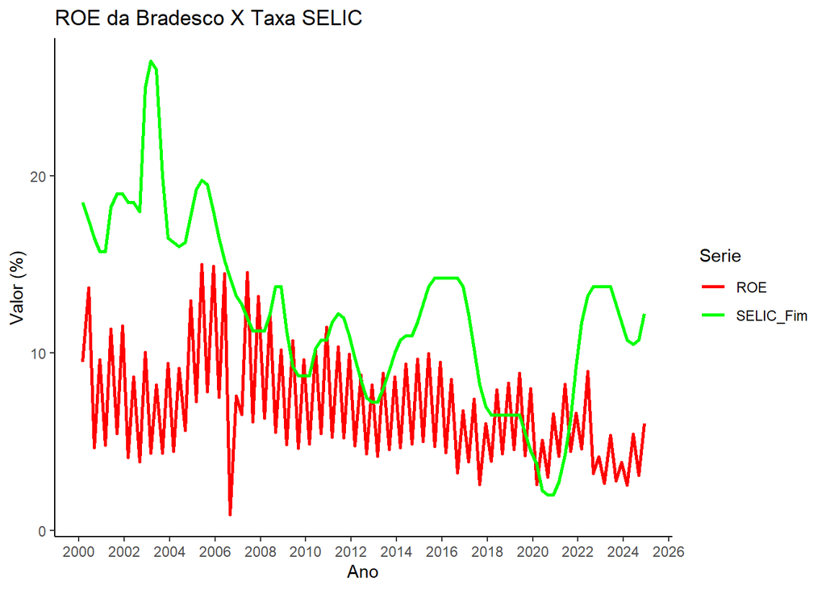

```r
ggplot(data = Dados_Longos_Simples_BRADESCO, aes(x = Data, y = Valor, group =
  Variavel, color = Variavel)) +
  geom_line(linewidth = 1) +
  scale_color_manual(
    values = c(
      "ROE" = "red",
      "SELIC_Fim" = "green" )) +
  scale_x_date(
    date_breaks = "2 year",
    date_labels = "%Y") +
  labs(
    title = "ROE da Bradesco X Taxa SELIC",
    x = "Ano",
    y = "Valor (%)",
    color = "Serie") +
  theme_classic()
```

### 4.4 Organizando a o df do ROE do ITAÚ e juntando a taxa SELIC

```r
ROE_ITAU_Simples <- ROE_ITAU %>%
  dplyr::select(Data, ROE) %>%
  mutate(Data = as.Date(paste0("01/", Data), format = "%d/%m/%Y"))

Dados_Simples_ITAU <- ROE_ITAU_Simples %>%
  left_join(SELIC_Simples, by = "Data") %>%
  na.omit()

Dados_Longos_Simples_ITAU <- Dados_Simples_ITAU %>%
  pivot_longer(
    cols = c(ROE, SELIC_Fim),
    names_to = "Variavel",
    values_to = "Valor")
```

#### - Apresentando os resultados do Itaú

```r
kable(
  head(ROE_ITAU, 20),
    col.names = c("Data", "Codigo", "Instituicao", "ROE")) %>%
  kable_styling(full_width = FALSE, bootstrap_options = c("striped"))
```

| Data | Codigo | Instituicao | ROE |
| --- | --- | --- | --- |
| 03/2000 | 10069 | ITAU | 4.954499 |
| 03/2001 | 10069 | ITAU | 7.624709 |
| 03/2002 | 10069 | ITAU | 3.981687 |
| 03/2003 | 10069 | ITAU | 9.059678 |
| 03/2004 | 10069 | ITAU | 6.594588 |
| 03/2005 | 10069 | ITAU | 7.729662 |
| 03/2006 | 10069 | ITAU | 10.551689 |
| 03/2007 | 10069 | ITAU | -5.566761 |
| 03/2008 | 10069 | ITAU | 6.586876 |
| 03/2009 | 10069 | ITAU | 4.329141 |
| 03/2010 | 10069 | ITAU | 6.049624 |
| 03/2011 | 10069 | ITAU | 5.463300 |
| 03/2012 | 10069 | ITAU | 4.618834 |
| 03/2013 | 10069 | ITAU | 3.645710 |
| 03/2014 | 10069 | ITAU | 4.280649 |
| 03/2015 | 10069 | ITAU | 5.606595 |
| 03/2016 | 10069 | ITAU | 3.995128 |
| 03/2017 | 10069 | ITAU | 4.455002 |
| 03/2018 | 10069 | ITAU | 4.196943 |
| 03/2019 | 10069 | ITAU | 4.973958 |

#### - Gráfico para verificar a relação entre as duas variaveis

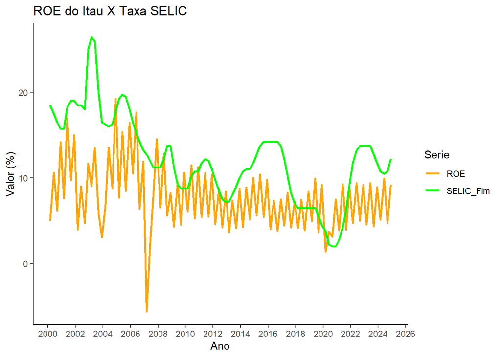

```r
ggplot(data = Dados_Longos_Simples_ITAU, aes(x = Data, y = Valor,
 group = Variavel, color = Variavel)) +
  geom_line(linewidth = 1) +
  scale_color_manual(
    values = c(
      "ROE" = "orange",
      "SELIC_Fim" = "green" )) +
  scale_x_date(
    date_breaks = "2 year",
    date_labels = "%Y") +
  labs(
    title = "ROE do Itau X Taxa SELIC",
    x = "Ano",
    y = "Valor (%)",
    color = "Serie") +
  theme_classic()
```

### 4.5 Organizando o df do ROE do SANTANDER e juntando a taxa SELIC

```r
ROE_SANTANDER_Simples <- ROE_SANTANDER %>%
  dplyr::select(Data, ROE) %>%
  mutate(Data = as.Date(paste0("01/", Data), format = "%d/%m/%Y"))

Dados_Simples_SANTANDER <- ROE_SANTANDER_Simples %>%
  left_join(SELIC_Simples, by = "Data") %>%
  na.omit()

Dados_Longos_Simples_SANTANDER <- Dados_Simples_SANTANDER %>%
  pivot_longer(
    cols = c(ROE, SELIC_Fim),
    names_to = "variavel",
    values_to = "Valor")
```

#### - Apresentando os resultados do do Santander

```r
kable(
  head(ROE_SANTANDER, 20),
    col.names = c("Data", "Instituicao", "Codigo", "ROE")) %>%
  kable_styling(full_width = FALSE, bootstrap_options = c("striped"))
```

| Data | Instituicao | Codigo | ROE |
| --- | --- | --- | --- |
| 03/2000 | SANTANDER BRASIL | 30379 | 2.5516445 |
| 03/2001 | SANTANDER BANESPA | 30379 | 4.6929442 |
| 03/2002 | SANTANDER BANESPA | 30379 | 8.8341900 |
| 03/2003 | SANTANDER BANESPA | 30379 | 8.0936527 |
| 03/2004 | SANTANDER BANESPA | 30379 | 4.7402810 |
| 03/2005 | SANTANDER BANESPA | 30379 | 3.6674789 |
| 03/2006 | SANTANDER BANESPA | 30379 | 5.6475667 |
| 03/2007 | SANTANDER BANESPA | 30379 | 6.3998274 |
| 03/2008 | SANTANDER | 30379 | 4.1396956 |
| 03/2009 | SANTANDER | 30379 | 0.8701846 |
| 03/2010 | SANTANDER | 30379 | 1.5654661 |
| 03/2011 | SANTANDER | 30379 | 1.5671581 |
| 03/2012 | SANTANDER | 30379 | 1.3234286 |
| 03/2013 | SANTANDER | 30379 | 1.0024006 |
| 03/2014 | SANTANDER | 30379 | 0.9511397 |
| 03/2015 | SANTANDER | 30379 | 1.2317713 |
| 03/2016 | SANTANDER | 30379 | 2.0396412 |
| 03/2017 | SANTANDER | 30379 | 2.9734625 |
| 03/2018 | SANTANDER | 30379 | 4.4873470 |
| 03/2019 | SANTANDER | 30379 | 4.9342753 |

#### - Gráfico para verificar a relação entre as duas variaveis

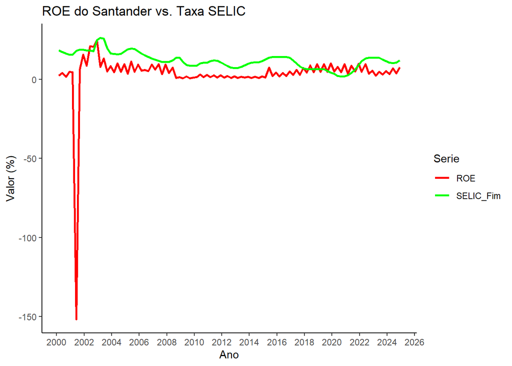

```r
ggplot(data = Dados_Longos_Simples_SANTANDER,
       aes(x = Data, y = Valor, group = variavel, color = variavel)) +
  geom_line(linewidth = 1) +
  scale_color_manual(
    values = c(
      "ROE" = "red",
      "SELIC_Fim" = "green" )) +
  scale_x_date(
    date_breaks = "2 year",
    date_labels = "%Y") +
  labs(
      title = "ROE do Santander vs. Taxa SELIC",
    x = "Ano",
    y = "Valor (%)",
    color = "Serie") +
  theme_classic()
```

#### Aqui a primeira supresa nos gráficos demonstrados, o ROE Santander reduziu muito no segundo trimestre de 2001 devido ao prejuízo e a redução do patrimonio líquido (resultado da compra do BANESPA). Como não foi possível encontrar RI da época, dificultou a interpretação dessa queda brusca. Entretanto, as notícias da época levam a crer nessa hipótese.

#### - Demonstração dos outliners

```r
kable(ROE_SANTANDER[c(2,27,51,75), ]) %>%
  kableExtra::kable_styling(full_width = FALSE)
```

|  | Data | Instituição | Código | ROE |
| --- | --- | --- | --- | --- |
| 2 | 03/2001 | SANTANDER BANESPA | 30379 | 4.692944 |
| 27 | 06/2001 | SANTANDER BANESPA | 30379 | -151.666711 |
| 51 | 09/2001 | SANTANDER BANESPA | 30379 | 6.397278 |
| 75 | 12/2001 | SANTANDER BANESPA | 30379 | 15.843552 |

### 4.6 Organizando o df do ROE do CAIXA e juntando a taxa SELIC

```r
ROE_CAIXA_Simples <- ROE_CAIXA %>%
  dplyr::select(Data, ROE) %>%
  mutate(Data = as.Date(paste0("01/", Data), format = "%d/%m/%Y"))

Dados_Simples_CAIXA <- ROE_CAIXA_Simples %>%
  left_join(SELIC_Simples, by = "Data") %>% na.omit()

Dados_Longos_Simples_CAIXA <- Dados_Simples_CAIXA %>%
  pivot_longer(
    cols = c(ROE, SELIC_Fim),
    names_to = "Variavel",
    values_to = "Valor")
```

##### - Apresentando os resultados do do Caixa

```r
kable(
  head(ROE_CAIXA, 20),
    col.names = c("Data", "Instituicao", "Codigo", "ROE")) %>%
  kable_styling(full_width = FALSE, bootstrap_options = c("striped"))
```

| Data | Instituicao | Codigo | ROE |
| --- | --- | --- | --- |
| 03/2000 | CAIXA ECONOMICA FEDERAL | 360305 | -3.837782 |
| 03/2001 | CAIXA ECONOMICA FEDERAL | 360305 | -3.179118 |
| 03/2002 | CAIXA ECONOMICA FEDERAL | 360305 | 5.260681 |
| 03/2003 | CAIXA ECONOMICA FEDERAL | 360305 | 6.616325 |
| 03/2004 | CAIXA ECONOMICA FEDERAL | 360305 | 6.653889 |
| 03/2005 | CAIXA ECONOMICA FEDERAL | 360305 | 6.806372 |
| 03/2006 | CAIXA ECONOMICA FEDERAL | 360305 | 8.211262 |
| 03/2007 | CAIXA ECONOMICA FEDERAL | 360305 | 7.924926 |
| 03/2008 | CAIXA ECONOMICA FEDERAL | 360305 | 7.731570 |
| 03/2009 | CAIXA ECONOMICA FEDERAL | 360305 | 3.482314 |
| 03/2010 | CAIXA ECONOMICA FEDERAL | 360305 | 5.662376 |
| 03/2011 | CAIXA ECONOMICA FEDERAL | 360305 | 4.647023 |
| 03/2012 | CAIXA ECONOMICA FEDERAL | 360305 | 5.672934 |
| 03/2013 | CAIXA ECONOMICA FEDERAL | 360305 | 5.151423 |
| 03/2014 | CAIXA ECONOMICA FEDERAL | 360305 | 5.659244 |
| 03/2015 | CAIXA ECONOMICA FEDERAL | 360305 | 4.436087 |
| 03/2016 | CAIXA ECONOMICA FEDERAL | 360305 | 2.064876 |
| 03/2017 | CAIXA ECONOMICA FEDERAL | 360305 | 5.295002 |
| 03/2018 | CAIXA ECONOMICA FEDERAL | 360305 | 7.456521 |
| 03/2019 | CAIXA ECONOMICA FEDERAL | 360305 | 7.984259 |

#### - Gráfico para verificar a relação entre as duas variaveis

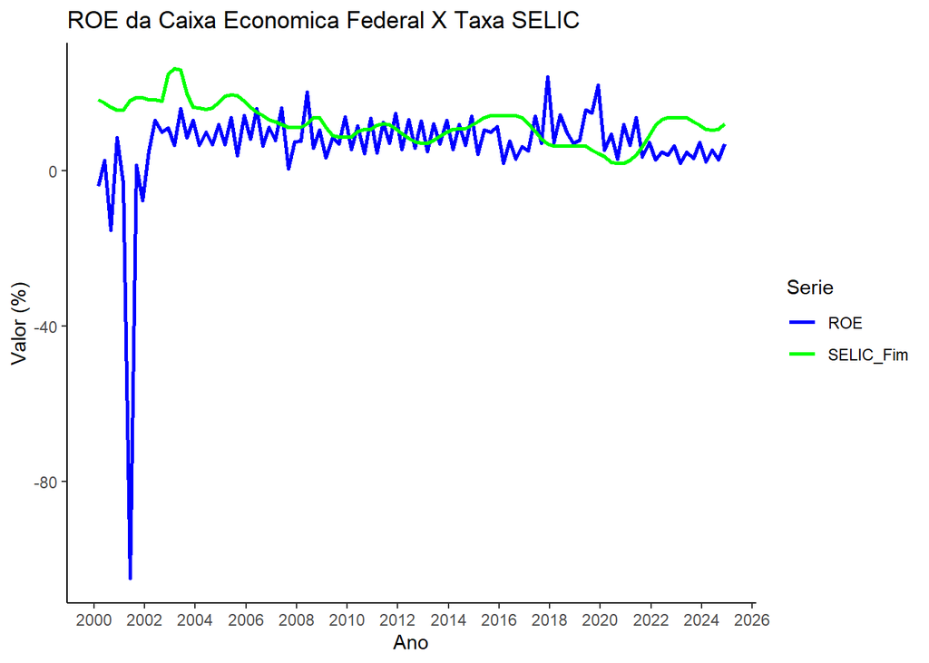

```r
ggplot(data = Dados_Longos_Simples_CAIXA, aes(x = Data, y = Valor, group =
  Variavel, color = Variavel)) +
  geom_line(linewidth = 1) +
  scale_color_manual(
    values = c(
      "ROE" = "blue",
      "SELIC_Fim" = "green" )) +
  scale_x_date(
    date_breaks = "2 year",
    date_labels = "%Y") +
  labs(
    title = "ROE da Caixa Economica Federal X Taxa SELIC",
    x = "Ano",
    y = "Valor (%)",
    color = "Serie") +
  theme_classic()
```

#### - Demonstração dos outliners

|  | Data | Instituição | Código | ROE |
| --- | --- | --- | --- | --- |
| 2 | 03/2001 | CAIXA ECONOMICA FEDERAL | 360305 | -3.179118 |
| 27 | 06/2001 | CAIXA ECONOMICA FEDERAL | 360305 | -104.861301 |
| 51 | 09/2001 | CAIXA ECONOMICA FEDERAL | 360305 | 1.560611 |
| 75 | 12/2001 | CAIXA ECONOMICA FEDERAL | 360305 | -7.547765 |

## 5 - Conclusão

#### Os bancos, na maior parte do tempo, apresentam retornos inferiores à taxa SELIC, o que é esperado, já que a taxa básica de juros serve como referência para a precificação e indexação de grande parte dos contratos do mercado financeiro. Ainda assim, é essencial analisar como as oscilações de uma variável se comportam em relação às mudanças da outra. Esse é justamente o objetivo do meu trabalho: explorar essa dinâmica, identificar padrões e investigar até que ponto uma alteração de 1 ponto percentual na SELIC pode influenciar o ROE no período seguinte.